# The natural disasters that have most affected the United States

Brayam Pineda

30/4/2021

## Abstract

The objetive of this analysis is to explore the NOAA Storm Database and answer some basic questions about severe weather events. In brief, the results show the “Tornado” was the most detrimental disaster in the list of events in the data. Hurricane/Typhoon are the second in the ranking.Furthermore, it was to plot two llolipop graphichs to show like the data is behaviored.

### Your data analysis must address the following questions:

#### 1. Across the United States, which types of events (as indicated in the EVTYPE variable) are most harmful with respect to population health?

#### 2. Across the United States, which types of events have the greatest economic consequences?

## Data Procesing

First one, import the libraries and determine a set.seed

```r
library(readr)
library(dplyr)

set.seed(1234)
```

Secod, call our data

```r
path = "repdata_data_StormData.csv.bz2"
data <- read_csv(path)
head(data)
```

```
## # A tibble: 6 x 37
##   STATE__ BGN_DATE   BGN_TIME TIME_ZONE COUNTY COUNTYNAME STATE EVTYPE BGN_RANGE
##     <dbl> <chr>      <chr>    <chr>      <dbl> <chr>      <chr> <chr>      <dbl>
## 1       1 4/18/1950~ 0130     CST           97 MOBILE     AL    TORNA~         0
## 2       1 4/18/1950~ 0145     CST            3 BALDWIN    AL    TORNA~         0
## 3       1 2/20/1951~ 1600     CST           57 FAYETTE    AL    TORNA~         0
## 4       1 6/8/1951 ~ 0900     CST           89 MADISON    AL    TORNA~         0
## 5       1 11/15/195~ 1500     CST           43 CULLMAN    AL    TORNA~         0
## 6       1 11/15/195~ 2000     CST           77 LAUDERDALE AL    TORNA~         0
## # ... with 28 more variables: BGN_AZI <lgl>, BGN_LOCATI <lgl>, END_DATE <lgl>,
## #   END_TIME <lgl>, COUNTY_END <dbl>, COUNTYENDN <lgl>, END_RANGE <dbl>,
## #   END_AZI <lgl>, END_LOCATI <lgl>, LENGTH <dbl>, WIDTH <dbl>, F <dbl>,
## #   MAG <dbl>, FATALITIES <dbl>, INJURIES <dbl>, PROPDMG <dbl>,
## #   PROPDMGEXP <chr>, CROPDMG <dbl>, CROPDMGEXP <lgl>, WFO <lgl>,
## #   STATEOFFIC <lgl>, ZONENAMES <lgl>, LATITUDE <dbl>, LONGITUDE <dbl>,
## #   LATITUDE_E <dbl>, LONGITUDE_ <dbl>, REMARKS <lgl>, REFNUM <dbl>
```

### Now, for the first question

It is necesary remake the data base to respond the question, in this case we need to count the number of the injuries by type of the event.

```r
evtype <- data %>% group_by(EVTYPE) %>% summarise(INJURIES = sum(INJURIES))
evtype <- evtype[order(evtype$INJURIES, decreasing = TRUE),]
head(evtype)
```

```
## # A tibble: 6 x 2
##   EVTYPE         INJURIES
##   <chr>             <dbl>
## 1 TORNADO           91346
## 2 TSTM WIND          6957
## 3 FLOOD              6789
## 4 EXCESSIVE HEAT     6525
## 5 LIGHTNING          5230
## 6 HEAT               2100
```

Now, we can to plot this information to do clearer the information, by avoiding the classic histogram it is posible plot a llolipop graph.

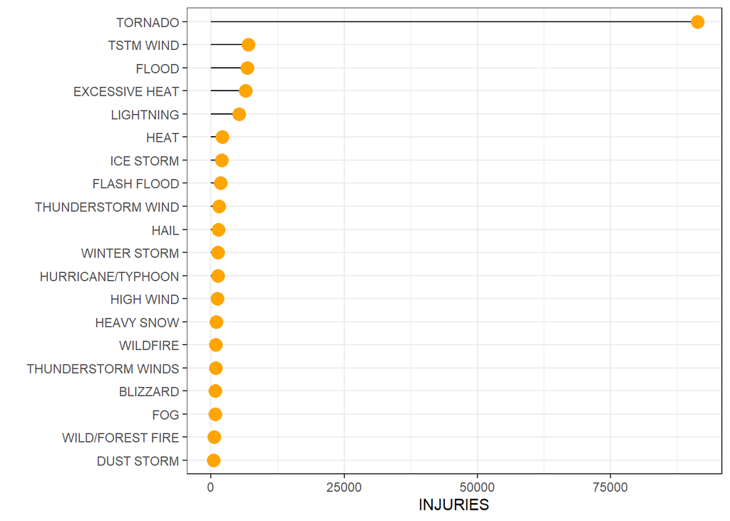

```r
library(ggplot2)
head(evtype, 20) %>%
  arrange(INJURIES) %>%    # First sort by val. This sort the dataframe but NOT the factor levels
  mutate(name = factor(EVTYPE, levels = EVTYPE)) %>%   # This trick update the factor levels
  ggplot( aes(x = name, y = INJURIES)) +
  geom_segment( aes(xend = name, yend=0)) +
  geom_point( size=4, color="orange") +
  coord_flip() +
  theme_bw() +
  xlab("")
```

In both graphs it is possible to observe that the type of event that causes the most injueries is the tornado followed by far by TSTM wind.

### The second question is

Across the United States, which types of events have the greatest economic consequences?

To answer is necesary to recode some variable in order to be able to be understandable by the program.

```r
data$PROPDMGEXP[data$PROPDMGEXP == ""] <- NA
data$PROPDMGEXP <- gsub("1", "10", data$PROPDMGEXP)
data$PROPDMGEXP <- gsub("NA", "1", data$PROPDMGEXP)
data$PROPDMGEXP <- gsub("\\-", "1", data$PROPDMGEXP)
data$PROPDMGEXP <- gsub("\\?", "1", data$PROPDMGEXP)
data$PROPDMGEXP <- gsub("\\+", "1", data$PROPDMGEXP)
data$PROPDMGEXP <- gsub("^0$", "1", data$PROPDMGEXP)
data$PROPDMGEXP <- gsub("h|H", "100", data$PROPDMGEXP)
data$PROPDMGEXP <- gsub("K", "1000", data$PROPDMGEXP)
data$PROPDMGEXP <- gsub("m|M", "1000000", data$PROPDMGEXP)
data$PROPDMGEXP <- gsub("B", "1000000000", data$PROPDMGEXP)
data$PROPDMGEXP <- gsub("2", "100", data$PROPDMGEXP)
data$PROPDMGEXP <- gsub("3", "1000", data$PROPDMGEXP)
data$PROPDMGEXP <- gsub("4", "10000", data$PROPDMGEXP)
data$PROPDMGEXP <- gsub("5", "100000", data$PROPDMGEXP)
data$PROPDMGEXP <- gsub("6", "1000000", data$PROPDMGEXP)
data$PROPDMGEXP <- gsub("7", "10000000", data$PROPDMGEXP)
data$PROPDMGEXP <- gsub("8", "100000000", data$PROPDMGEXP)


data$PROPDMGEXP <- as.numeric(data$PROPDMGEXP)
```

After that is posible to remake the data to get clarer information.

```r
propdmgexp <- data %>% group_by(EVTYPE) %>% summarise("PROPERTY DAMAGED" = sum(PROPDMGEXP, na.rm = TRUE))
propdmgexp <- propdmgexp[order(propdmgexp$`PROPERTY DAMAGED`, decreasing = TRUE), ]
head(propdmgexp)
```

```
## # A tibble: 6 x 2
##   EVTYPE            `PROPERTY DAMAGED`
##   <chr>                          <dbl>
## 1 HURRICANE/TYPHOON        12046012000
## 2 TORNADO                   7533649060
## 3 FLOOD                     6541863001
## 4 HURRICANE                 3077046000
## 5 FLASH FLOOD               2553640012
## 6 HAIL                      2068898545
```

Now the information is ready to the visualization

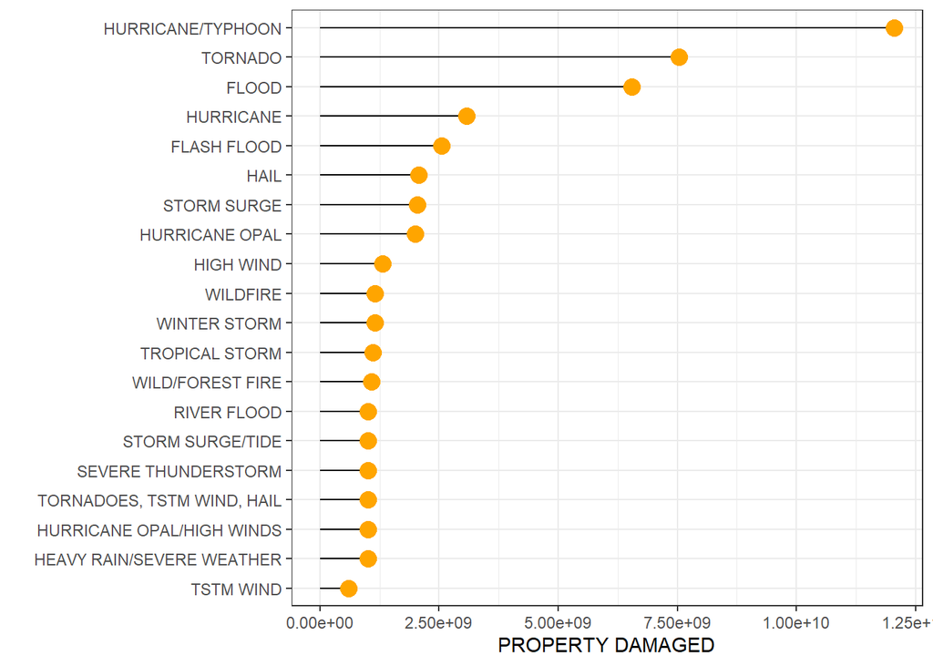

```r
head(propdmgexp[propdmgexp$EVTYPE != "?", ], 20) %>%
  arrange(`PROPERTY DAMAGED`) %>%    # First sort by val. This sort the dataframe but NOT the factor levels
  mutate(name = factor(EVTYPE, levels = EVTYPE)) %>%   # This trick update the factor levels
  ggplot( aes(x = name, y = `PROPERTY DAMAGED`)) +
  geom_segment( aes(xend = name, yend=0)) +
  geom_point( size=4, color="orange") +
  coord_flip() +
  theme_bw() +
  xlab("")
```

## Results

As was possible to observe from the graphics the Tornado was the more harmful event which to affected to United States in the past years, however hurricane or typhoon were the disaster which more affected to economic. Also Tornado was included in the last actegory where it get the second place. In brief Tornado is the most detrimental type of event in the information.